# Mortality Analysis for 2016: Models and Tests

Tamara Cooper

2024-01-22

### Purpose and Goals

The purpose of this code is to perform various statistical analyses on the mortality data in the nc2016.csv data set that I prepared in the data aggregation project. (Please see the 2016Mort_dataAggr.html and 2016Mort_explorAna.html files to view the data aggregation and exploratory analysis projects.)  
My goals for this project are to check independence and variance, perform regression analyses, and test for any interaction effects. I will also check the data for spatial dependence and perform a spatial regression analysis if spatial dependence is found.

#### How to read this document

Before we begin the analyses here is a brief explanation of the layout of this document and what each of the parts are.  
This page displays code, output, and discussions about the output. The layout is as follows:  
1. Code is displayed in gray “code boxes”

```r
# This is a code box
x <- c(1,3,2,4,8,4,7)
y <- c(9,3,1,5,7,2,6)
plot(x, y, col='#04918a', main="Output of code", type = "p", pch = 19)
```

2. Output of the code

[figure not shown]

3. Discussion about results/findings

### Bring in the data set

```r
nc2016 <- read.csv("./output/nc2016.csv")
nc2016
```

| FIPS | state | county | mentUnhDays | perAccToExer | perExcDrink | Unemploy | laborForce | perUnemploy | perInsSleep | population | black | amerIndAlas | asian | natHawPacIs | hispanic | nonHisWht | foodEnvIndx | chlamyd | perChlamyd | tBirthRate | tBirthRBlk | tBirthRHis | tBirthRWht | violenCrime | vioCrimeRate | Deaths | crudeRate | ageAdjRate |
| --- | --- | --- | --- | --- | --- | --- | --- | --- | --- | --- | --- | --- | --- | --- | --- | --- | --- | --- | --- | --- | --- | --- | --- | --- | --- | --- | --- | --- |
| 37001 | North Carolina | Alamance | 4.285 | 85.65 | 15.69 | 3737 | 78973 | 4.732 | 33.32 | 159688 | 30793 | 2278 | 2544 | 140 | 20069 | 103147 | 7.1 | 1086 | 0.006971 | 0.027052 | 35.74 | 53.46 | 19.104 | 615.000 | 0.0039639 | 1639 | 10.264 | 8.044 |
| 37003 | North Carolina | Alexander | 4.198 | 19.33 | 16.73 | 767 | 17910 | 4.283 | 33.02 | 37428 | 2095 | 197 | 424 | 16 | 1740 | 32541 | 8.0 | 72 | 0.001926 | 0.032193 | 24.81 | 32.00 | 32.116 | 48.333 | 0.0013038 | 376 | 10.046 | 7.673 |
| 37005 | North Carolina | Alleghany | 4.256 | 67.06 | 14.83 | 248 | 4461 | 5.559 | 32.52 | 10848 | 164 | 62 | 78 | 4 | 1040 | 9439 | 8.2 | 23 | 0.002114 | 0.041431 | NA | 78.19 | 38.079 | 15.000 | 0.0013748 | 150 | 13.827 | 8.431 |
| 37007 | North Carolina | Anson | 4.313 | 59.98 | 14.80 | 621 | 10777 | 5.762 | 37.30 | 25448 | 12326 | 221 | 277 | 17 | 1034 | 11367 | 6.3 | 198 | 0.007685 | 0.046230 | 58.88 | 75.27 | 24.041 | 119.000 | 0.0051365 | 321 | 12.614 | 10.106 |
| 37009 | North Carolina | Ashe | 4.124 | 58.54 | 15.93 | 606 | 12559 | 4.825 | 31.90 | 26924 | 182 | 87 | 151 | 12 | 1422 | 24849 | 8.0 | 25 | 0.000922 | 0.038012 | NA | 56.55 | 37.291 | 21.333 | 0.0007832 | 327 | 12.145 | 7.746 |
| 37011 | North Carolina | Avery | 4.154 | 100.00 | 17.58 | 386 | 7650 | 5.046 | 30.92 | 17516 | 724 | 102 | 104 | 10 | 919 | 15560 | 8.3 | 17 | 0.000957 | 0.024466 | NA | 56.12 | 24.146 | 24.333 | 0.0013851 | 193 | 11.018 | 7.543 |
| 37013 | North Carolina | Beaufort | 4.132 | 60.54 | 15.58 | 1162 | 20429 | 5.688 | 31.52 | 47526 | 11610 | 490 | 243 | 31 | 3728 | 31306 | 7.3 | 273 | 0.005737 | 0.040423 | 56.91 | 67.81 | 27.128 | 154.333 | 0.0032874 | 616 | 12.961 | 8.822 |
| 37015 | North Carolina | Bertie | 4.226 | 33.49 | 12.97 | 568 | 8537 | 6.653 | 38.04 | 19854 | 12143 | 131 | 123 | 20 | 414 | 6884 | 6.3 | 201 | 0.009997 | 0.039621 | 45.68 | NA | 23.011 | 31.667 | 0.0015380 | 241 | 12.139 | 8.316 |
| 37017 | North Carolina | Bladen | 4.585 | 35.61 | 13.37 | 1020 | 14723 | 6.928 | 35.19 | 33741 | 11331 | 1026 | 112 | 11 | 2605 | 18483 | 6.6 | 191 | 0.005511 | 0.037606 | 33.99 | 51.90 | 36.325 | 91.000 | 0.0025991 | 417 | 12.359 | 9.226 |
| 37019 | North Carolina | Brunswick | 3.932 | 76.56 | 15.34 | 3158 | 49758 | 6.347 | 30.69 | 126953 | 13144 | 1056 | 915 | 158 | 5980 | 104035 | 7.6 | 355 | 0.002987 | 0.032700 | 31.11 | 51.80 | 31.028 | 191.000 | 0.0017117 | 1397 | 11.004 | 7.167 |

[output cut: 90 more lines]

### Multiple Linear Regression Model

From the exploratory analysis performed in the 2016Mort_explorAna.html file I decided to perform the regression analysis on the following variables:  
ageAdjRate - the age adjusted mortality rate for NC 2016, dependent variable  
Independent variables:  
mentUnhDays - poor mental health days  
perAccToExer - percent with access to exercise opportunities  
perExcDrink - percent excessive drinking  
perUnemploy - unemployment Rate  
perChlamyd - percent Chlamydia cases  
tBirthRate - teen births rate  
vioCrimeRate - violent crime rate  
perInsSleep - percent insufficient sleep

#### Model 1

```r
mod <- lm(ageAdjRate ~ mentUnhDays + perAccToExer + perExcDrink + tBirthRate + vioCrimeRate + perInsSleep + perChlamyd + perUnemploy, data = nc2016)
summary(mod)
```

```
##
## Call:
## lm(formula = ageAdjRate ~ mentUnhDays + perAccToExer + perExcDrink +
##     tBirthRate + vioCrimeRate + perInsSleep + perChlamyd + perUnemploy,
##     data = nc2016)
##
## Residuals:
##     Min      1Q  Median      3Q     Max
## -2.2097 -0.3544  0.0242  0.3665  1.9627
##
## Coefficients:
##               Estimate Std. Error t value Pr(>|t|)
## (Intercept)    3.82274    2.17338    1.76    0.082 .
## mentUnhDays    0.56322    0.37351    1.51    0.135
## perAccToExer  -0.01218    0.00494   -2.46    0.016 *
## perExcDrink    0.06013    0.05655    1.06    0.291
## tBirthRate    43.67295    9.36018    4.67 0.000011 ***
## vioCrimeRate 132.66572   71.84204    1.85    0.068 .
## perInsSleep   -0.00678    0.05915   -0.11    0.909
## perChlamyd   -24.31497   50.99676   -0.48    0.635
## perUnemploy    0.07988    0.10418    0.77    0.445
## ---
## Signif. codes:  0 '***' 0.001 '**' 0.01 '*' 0.05 '.' 0.1 ' ' 1
##
## Residual standard error: 0.698 on 86 degrees of freedom
##   (5 observations deleted due to missingness)
## Multiple R-squared:  0.528,  Adjusted R-squared:  0.484
## F-statistic:   12 on 8 and 86 DF,  p-value: 0.0000000000222
```

From the model we see that the perAccToExer and tBirthRate variables are significant at the α = 0.05 and α = 0.001 levels, respectively. We also see that the vioCrimeRate variable is significant at the α = 0.1 level. Next I will perform some residual diagnostics to check that the model doesn’t violate the normality, linearity, and homoscedasticity assumptions.

##### Model 1 - Residual Diagnostics

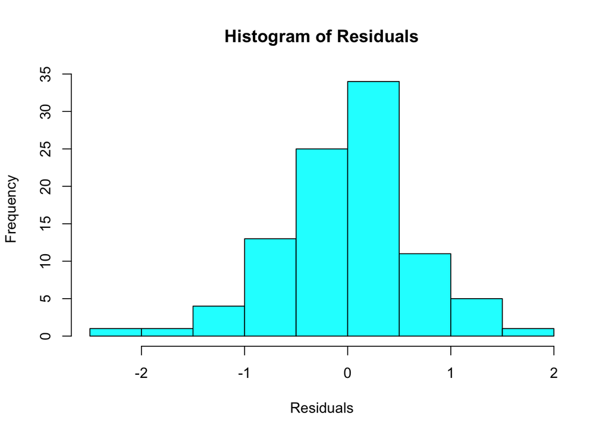

```r
mod_res <- mod$residuals

# Histogram of residuals
hist(mod_res, main = "Histogram of Residuals", col = "cyan", xlab="Residuals")
```

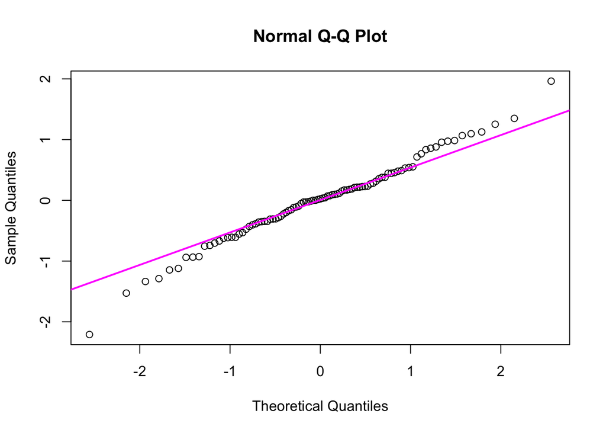

```r
# Normal Q-Q plot
qqnorm(mod_res)
qqline(mod_res, col = "magenta", lwd = 2)
```

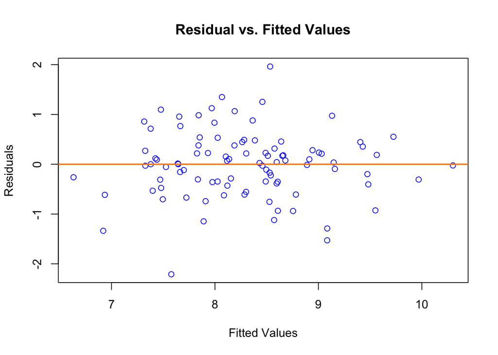

```r
# Residuals vs. fitted values
plot(fitted(mod), mod_res, title("Residual vs. Fitted Values"), xlab="Fitted Values", ylab="Residuals", col="blue")
abline(0, 0, col="darkorange", lwd = 2)
```

From the histogram of the model residuals we see that the residuals follow a normal distribution and the normality assumption is not violated.  
The Normal Q-Q Plot shows us that the data are normally distributed and thus the normality assumption is not violated.  
And from the plot of the residuals vs. the fitted values we see that the residuals are randomly distributed around the 0 line, showing us that the relationship is linear. We see homogeneity of error variance since the residuals form an approximately horizontal band about the 0 line, thus the homoscedasticity assumption is not violated. Finally, we see the possibility of a couple of outliers at y = 2 and y = -2 but since they are not extremely far from the random pattern we may only take note of them at this time.

#### Model 2

I now run a model with only the variables that were found to be significant in Model 1.

```r
mod_2 <- lm(ageAdjRate ~ perAccToExer + tBirthRate + vioCrimeRate, data = nc2016)
summary(mod_2)
```

```
##
## Call:
## lm(formula = ageAdjRate ~ perAccToExer + tBirthRate + vioCrimeRate,
##     data = nc2016)
##
## Residuals:
##     Min      1Q  Median      3Q     Max
## -2.3298 -0.3983  0.0282  0.3814  1.9939
##
## Coefficients:
##               Estimate Std. Error t value      Pr(>|t|)
## (Intercept)    7.02783    0.41968   16.75       < 2e-16 ***
## perAccToExer  -0.01147    0.00406   -2.83        0.0058 **
## tBirthRate    49.34160    7.23891    6.82 0.00000000099 ***
## vioCrimeRate 123.80238   50.05682    2.47        0.0152 *
## ---
## Signif. codes:  0 '***' 0.001 '**' 0.01 '*' 0.05 '.' 0.1 ' ' 1
##
## Residual standard error: 0.695 on 91 degrees of freedom
##   (5 observations deleted due to missingness)
## Multiple R-squared:  0.506,  Adjusted R-squared:  0.49
## F-statistic: 31.1 on 3 and 91 DF,  p-value: 6.28e-14
```

In Model 2 we see that all the variables are significant at the α = 0.05 level and below, with tBirthRate being the most highly significant.  
The adjusted R-squared value for this model is 0.49 which is slightly higher than the adjusted R-squared value of Model 1, 0.484, so we see that Model 2 is better (very slightly better).

##### Model 2 - Residual Diagnostics

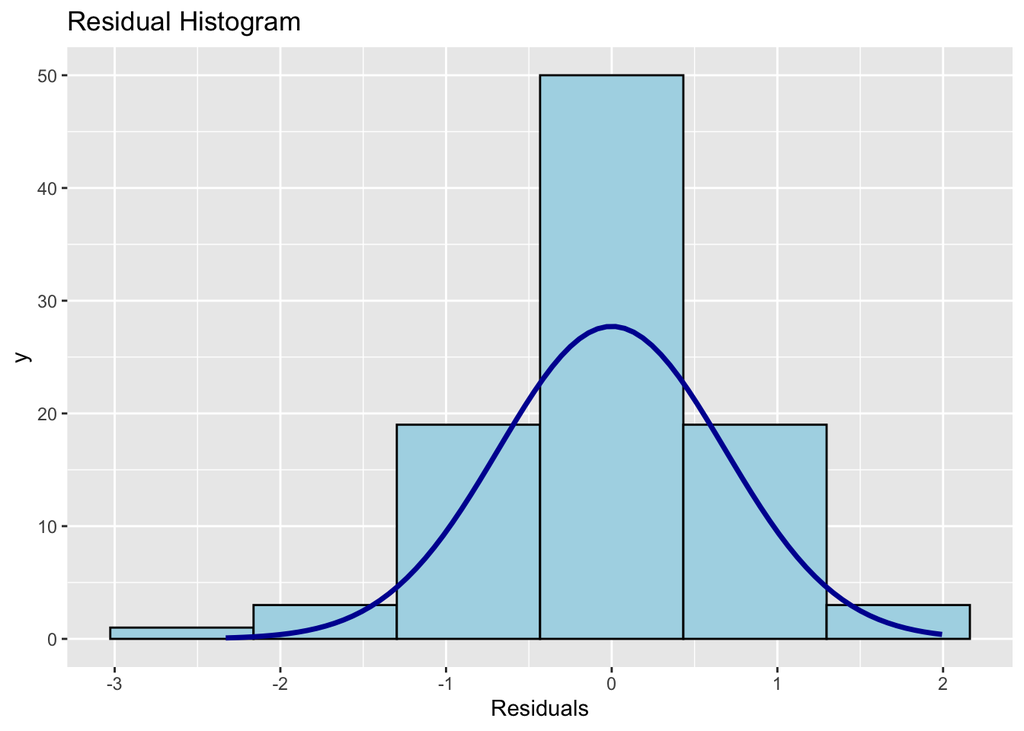

```r
# Histogram of residuals
ols_plot_resid_hist(mod_2)
```

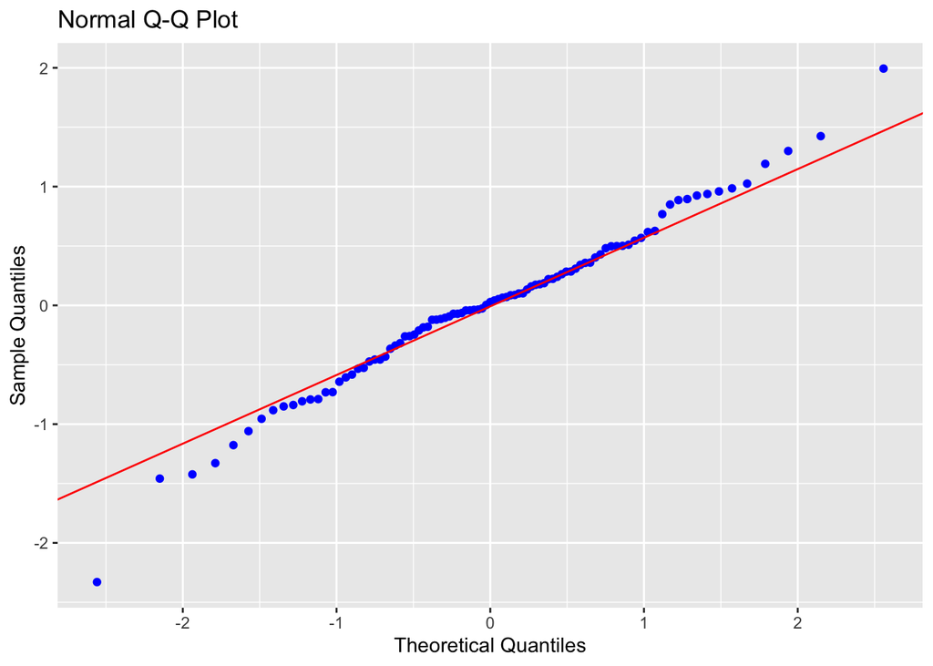

```r
# Normal Q-Q plot
ols_plot_resid_qq(mod_2)
```

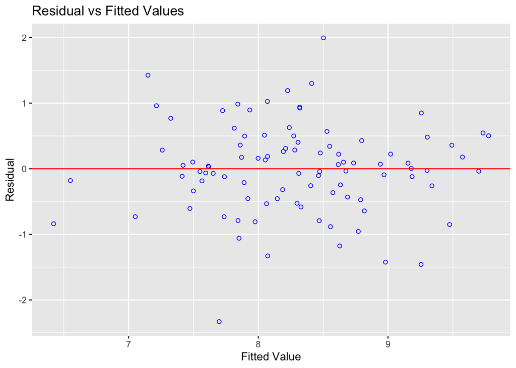

```r
# Residuals vs. fitted values
ols_plot_resid_fit(mod_2)
```

For the residual diagnostics of Model 2 I applied the oslrr package to create the same plots I created for Model 1. From the above plots we see that the linearity, normality, and homoscedasticity assumptions are met.

### Check for interaction effects

```r
mod_3 <- lm(ageAdjRate ~ (perAccToExer + tBirthRate + vioCrimeRate)^2, data = nc2016)
summary(mod_3)
```

```
##
## Call:
## lm(formula = ageAdjRate ~ (perAccToExer + tBirthRate + vioCrimeRate)^2,
##     data = nc2016)
##
## Residuals:
##     Min      1Q  Median      3Q     Max
## -2.4194 -0.3528  0.0247  0.3956  2.0734
##
## Coefficients:
##                            Estimate Std. Error t value     Pr(>|t|)
## (Intercept)                  7.7529     1.1607    6.68 0.0000000021 ***
## perAccToExer                -0.0151     0.0141   -1.07        0.287
## tBirthRate                  -2.4278    32.3593   -0.08        0.940
## vioCrimeRate               437.4823   328.9275    1.33        0.187
## perAccToExer:tBirthRate      0.5368     0.4043    1.33        0.188
## perAccToExer:vioCrimeRate   -5.9428     3.1793   -1.87        0.065 .
## tBirthRate:vioCrimeRate   3165.8022  4386.3639    0.72        0.472
## ---
## Signif. codes:  0 '***' 0.001 '**' 0.01 '*' 0.05 '.' 0.1 ' ' 1
##
## Residual standard error: 0.683 on 88 degrees of freedom
##   (5 observations deleted due to missingness)
## Multiple R-squared:  0.539,  Adjusted R-squared:  0.507
## F-statistic: 17.1 on 6 and 88 DF,  p-value: 5.14e-13
```

```r
mod_4 <- lm(ageAdjRate ~ perAccToExer + tBirthRate + vioCrimeRate + tBirthRate*vioCrimeRate, data = nc2016)
summary(mod_4)
```

```
##
## Call:
## lm(formula = ageAdjRate ~ perAccToExer + tBirthRate + vioCrimeRate +
##     tBirthRate * vioCrimeRate, data = nc2016)
##
## Residuals:
##    Min     1Q Median     3Q    Max
## -2.380 -0.403  0.048  0.369  2.030
##
## Coefficients:
##                           Estimate Std. Error t value Pr(>|t|)
## (Intercept)                7.58213    0.56474   13.43   <2e-16 ***
## perAccToExer              -0.01089    0.00406   -2.69   0.0086 **
## tBirthRate                32.85789   13.41413    2.45   0.0162 *
## vioCrimeRate            -103.79408  164.04488   -0.63   0.5285
## tBirthRate:vioCrimeRate 6037.90197 4146.97228    1.46   0.1489
## ---
## Signif. codes:  0 '***' 0.001 '**' 0.01 '*' 0.05 '.' 0.1 ' ' 1
##
## Residual standard error: 0.69 on 90 degrees of freedom
##   (5 observations deleted due to missingness)
## Multiple R-squared:  0.518,  Adjusted R-squared:  0.496
## F-statistic: 24.1 on 4 and 90 DF,  p-value: 1.38e-13
```

With Model 4 we see that perAccToExer and tBirthRate have some significance and the adjusted R-squared is 0.496 which is better than Model 2 (again only slightly better).  
Next I will check for spatial dependence.

### Moran’s I test for spatial dependence

#### Bring in the spatial data

I created the spatial data files in QGIS by joining the above data file to the 2016 TIGER/Line NHGIS data that I collected from IPUMS NHGIS https://www.nhgis.org/.

```
##  [1] "STATEFP"    "COUNTYFP"   "COUNTYNS"   "GEOID"      "NAME"
##  [6] "NAMELSAD"   "LSAD"       "CLASSFP"    "MTFCC"      "CSAFP"
## [11] "CBSAFP"     "METDIVFP"   "FUNCSTAT"   "ALAND"      "AWATER"
## [16] "INTPTLAT"   "INTPTLON"   "GISJOIN"    "Shape_Leng" "Shape_Area"
## [21] "FIPS"       "state"      "county"     "mentUnhDay" "perAccToEx"
## [26] "perExcDrin" "Unemploy"   "laborForce" "perUnemplo" "perInsSlee"
## [31] "population" "black"      "amerIndAla" "asian"      "natHawPacI"
## [36] "hispanic"   "nonHisWht"  "foodEnvInd" "chlamyd"    "perChlamyd"
## [41] "tBirthRate" "tBirthRBlk" "tBirthRHis" "tBirthRWht" "violenCrim"
## [46] "vioCrimeRa" "Deaths"     "crudeRate"  "ageAdjRate"
```

#### Bring in only the shape file

```r
shapeFile <- st_read("./SpatialData/nc_mort16_spat.shp")   ### bring in the shape file
# names(shapeFile)   ### list the column names
```

#### Define neighboring polygons and assign weights

```r
nb <- poly2nb(shapeFile, queen = TRUE)  ### define the neighboring polygons based on the queen case
nb
```

```
## Neighbour list object:
## Number of regions: 100
## Number of nonzero links: 488
## Percentage nonzero weights: 4.88
## Average number of links: 4.88
```

```r
lw <- nb2listw(nb, style = "W", zero.policy = TRUE)  ### assign weights
```

#### Create a scatter plot between age adjusted mortality rate values and their lagged counterparts

Just for fun here’s a scatter plot of the rate values with the lagged values

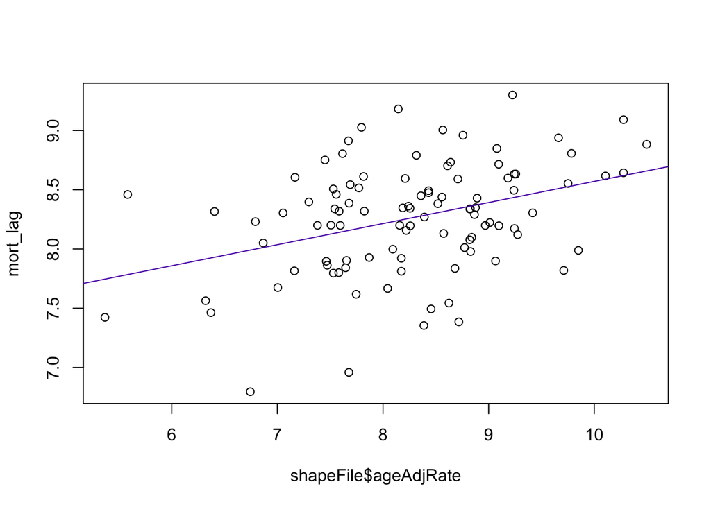

```r
mort_lag <- lag.listw(lw, shapeFile$ageAdjRate)
# mort_lag   ### Lagged values

plot(mort_lag ~ shapeFile$ageAdjRate)
mort_line <- lm(mort_lag ~ shapeFile$ageAdjRate)
abline(mort_line, col="#5A01B3")
```

##### Compute the slope of the line

```r
### compute the slope of the line which is the Moran's I coefficient
coef(mort_line)[2]
```

```
## shapeFile$ageAdjRate
##               0.1781
```

The computed slope of the model is the Moran’s I coefficient.

##### Compute the Moran’s I statistic

```r
### compute Moran's I statistic
mI_stat <- moran(shapeFile$ageAdjRate, lw, length(nb), Szero(lw))[1]
mI_stat
```

```
## $I
## [1] 0.1781
```

Note that the Moran’s I statistic is equal to the computed slope of the model.

#### Moran’s I hypothesis test

We will test the following hypothesis:  
H_0: The age adjusted mortality rate values are randomly distributed across counties following a completely random process.  
H_1: The age adjusted mortality rate values are not randomly distributed across counties.  
We will test this at the α = 0.05 level.

##### Moran’s I test - Analytical Method

```r
### Moran's I hypothesis test
moran.test(shapeFile$ageAdjRate, lw, alternative = "greater")
```

```
##
##  Moran I test under randomisation
##
## data:  shapeFile$ageAdjRate
## weights: lw
##
## Moran I statistic standard deviate = 2.9, p-value = 0.002
## alternative hypothesis: greater
## sample estimates:
## Moran I statistic       Expectation          Variance
##          0.178150         -0.010101          0.004257
```

We see that the p-value = 0.002 < α = 0.05 so we reject the null hypothesis and concluded that there is spatial dependence.  
The analytical method may be sensitive to irregularly distributed polygons and a safer method is the Monte Carlo simulation seen below.

##### Moran’s I test - Monte Carlo Method

```r
### Moran's I hypothesis test using the Monte Carlo method
mc <- moran.mc(shapeFile$ageAdjRate, lw, nsim = 9999, alternative = "greater")
mc
```

```
##
##  Monte-Carlo simulation of Moran I
##
## data:  shapeFile$ageAdjRate
## weights: lw
## number of simulations + 1: 10000
##
## statistic = 0.18, observed rank = 9971, p-value = 0.003
## alternative hypothesis: greater
```

With the Monte Carlo approach we see that the p-value = 0.003 < α = 0.05 so we reject the null hypothesis and concluded that there is spatial dependence.

#### Plot the Density of Permutation Outcomes

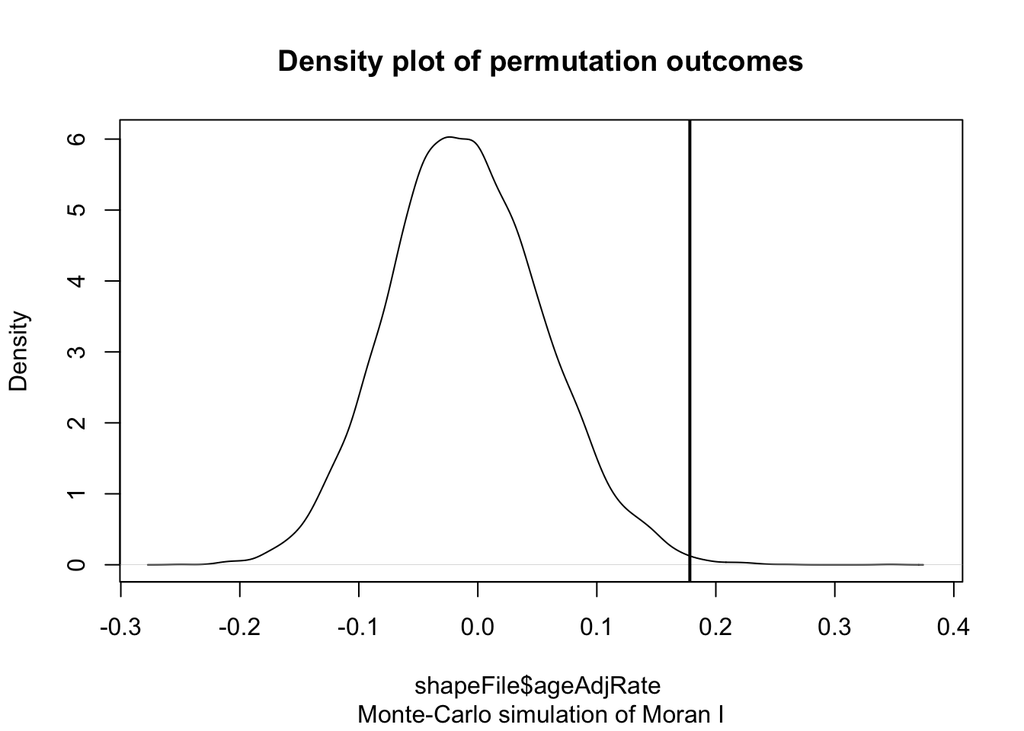

```r
### density plot of the null distribution
plot(mc)
```

In the density plot of permutation outcomes is a graphical representation of the Monte Carlo method. The curve shows the distribution of Moran I values we could expect if the age adjusted mortality rate were randomly distributed across the counties. Note that the observed statistic, 0.1781, falls in the right tail of the distribution suggesting that the mortality rate values are clustered. A negative Moran’s I value would suggest dispersion.

#### Map the 2016 Age Adjusted Mortality Rate

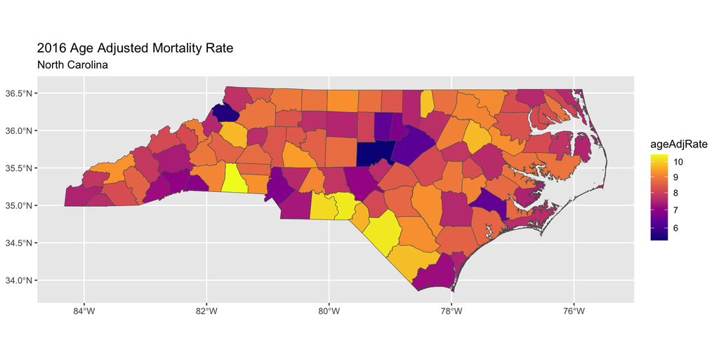

```r
nc_shp <- read_sf("./SpatialData/nc_mort16_spat.shp")
ggplot(data = nc_shp) + geom_sf(aes(fill = ageAdjRate)) +
  scale_fill_viridis_c(option = "plasma", trans = "sqrt") +
  coord_sf(crs = st_crs(4326)) +
  ggtitle(label = "2016 Age Adjusted Mortality Rate", subtitle = "North Carolina")
```

Dark blue counties have a lower mortality rate and yellow counties have the highest mortality rates in this data.

#### Spatial Regression Analyses

Since we found spatial dependence in the data I will run a spatial regression analysis on Model 4.

#### Lagrange Multiplier Tests

```r
m4 <- ageAdjRate ~ perAccToEx + tBirthRate + vioCrimeRa + tBirthRate*vioCrimeRa
# lm.morantest(lm(m4, data = spat.dat), listw = lw)   ## another Moran's test
lm.LMtests(lm(m4, data = spat.dat), listw = lw, test = "all")
```

```
##
##  Lagrange multiplier diagnostics for spatial dependence
##
## data:
## model: lm(formula = m4, data = spat.dat)
## weights: lw
##
## LMerr = 4.6, df = 1, p-value = 0.03
##
##
##  Lagrange multiplier diagnostics for spatial dependence
##
## data:
## model: lm(formula = m4, data = spat.dat)
## weights: lw
##
## LMlag = 1.8, df = 1, p-value = 0.2
##
##
##  Lagrange multiplier diagnostics for spatial dependence
##
## data:
## model: lm(formula = m4, data = spat.dat)
## weights: lw
##
## RLMerr = 3.3, df = 1, p-value = 0.07
##
##
##  Lagrange multiplier diagnostics for spatial dependence
##
## data:
## model: lm(formula = m4, data = spat.dat)
## weights: lw
##
## RLMlag = 0.55, df = 1, p-value = 0.5
##
##
##  Lagrange multiplier diagnostics for spatial dependence
##
## data:
## model: lm(formula = m4, data = spat.dat)
## weights: lw
##
## SARMA = 5.1, df = 2, p-value = 0.08
```

The Lagrange multiplier tests are another way to determine if there is spatial dependence. From the p-value results of the above tests we see that only in the case of LMerr do we reject the null hypothesis at α = 0.05 and so we should use a spatial error model.  
I will run four spatial regression models to demonstrate them but note that the above Lagrange multiplier test only found that our model could be improved with a spatial error model, SEM model.

##### SLX Spatially Lagged X

```r
mod_lagX <- lmSLX(m4, data = spat.dat, listw = lw)
summary(mod_lagX)
```

```
##
## Call:
## lm(formula = formula(paste("y ~ ", paste(colnames(x)[-1], collapse = "+"))),
##     data = as.data.frame(x), weights = weights)
##
## Residuals:
##     Min      1Q  Median      3Q     Max
## -2.4054 -0.3225  0.0613  0.3435  1.9503
##
## Coefficients:
##                              Estimate  Std. Error t value    Pr(>|t|)
## (Intercept)                   7.28588     1.24390    5.86 0.000000084 ***
## perAccToEx                   -0.01385     0.00508   -2.72      0.0078 **
## tBirthRate                   32.82136    13.63857    2.41      0.0182 *
## vioCrimeRa                  -90.29342   169.75777   -0.53      0.5962
## tBirthRate.vioCrimeRa      6320.64114  4258.99720    1.48      0.1414
## lag.perAccToEx                0.00318     0.00767    0.41      0.6796
## lag.tBirthRate               13.84085    29.33816    0.47      0.6383
## lag.vioCrimeRa               78.74728   352.91208    0.22      0.8240
## lag.tBirthRate.vioCrimeRa -4836.68738  9539.02448   -0.51      0.6134
## ---
## Signif. codes:  0 '***' 0.001 '**' 0.01 '*' 0.05 '.' 0.1 ' ' 1
##
## Residual standard error: 0.7 on 86 degrees of freedom
## Multiple R-squared:  0.526,  Adjusted R-squared:  0.482
## F-statistic: 11.9 on 8 and 86 DF,  p-value: 0.0000000000272
```

```r
summary(impacts(mod_lagX, listw = lw, R = 500), zstats = TRUE)
```

```
## Impact measures (SlX, glht, n-k):
##                           Direct     Indirect      Total
## perAccToEx              -0.01385     0.003177   -0.01067
## tBirthRate              32.82136    13.840846   46.66221
## vioCrimeRa             -90.29342    78.747284  -11.54613
## tBirthRate:vioCrimeRa 6320.64114 -4836.687377 1483.95377
## ========================================================
## Standard errors:
##                            Direct    Indirect       Total
## perAccToEx               0.005082    0.007666     0.00698
## tBirthRate              13.638568   29.338155    32.69611
## vioCrimeRa             169.757772  352.912077   388.29002
## tBirthRate:vioCrimeRa 4258.997195 9539.024477 10263.60597
## ========================================================
## Z-values:
##                        Direct Indirect    Total
## perAccToEx            -2.7248   0.4145 -1.52854
## tBirthRate             2.4065   0.4718  1.42715
## vioCrimeRa            -0.5319   0.2231 -0.02974
## tBirthRate:vioCrimeRa  1.4841  -0.5070  0.14458
##
## p-values:
##                       Direct Indirect Total
## perAccToEx            0.0064 0.68     0.13
## tBirthRate            0.0161 0.64     0.15
## vioCrimeRa            0.5948 0.82     0.98
## tBirthRate:vioCrimeRa 0.1378 0.61     0.89
```

The SLX Spatially Lagged X model, y = Xβ + WXθ + ε, includes the average values of neighboring counties’ percent access to exercise, teen birth rate, violent crime rate, teen birth rate and violent crime rate interaction. This is a Local Spatial Model.  
We see with this model that perAccToEx and tBirthRate are significant variables at the α = 0.01 and α = 0.05 levels, respectively.  
Compared to the OLS Model 4, ageAdjRate = perAccToExer + tBirthRate + vioCrimeRate + tBirthRate*vioCrimeRate, we see that the Intercept, perAccToEx, and tBirthRate are significant at the same level in both models but the adjusted R-squared of the OLS Model 4 is slightly better at 0.496.  
The impacts(.) function shows us the total affects, where in the SLX model we see the direct affect from the X values and the indirect affect from the lagged X values. From the p-values printed out from the impacts(.) function we see that the total affects are not significant.

##### Spatial Autoregressive (SAR) - Spatial Lag Model

```r
spat.dat_2 <- readOGR(dsn = "./SpatDat_noNA", layer = "nc_mort16_spat_noNA")  ## bring in no NA spatial files
shp <- st_read("./SpatDat_noNA/nc_mort16_spat_noNA.shp")   ### bring in the shape file, data without NA's
nb_2 <- poly2nb(shp, queen = TRUE)  ### define the neighboring polygons based on the queen case
lw_2 <- nb2listw(nb_2, style = "W", zero.policy = TRUE)  ### assign weights

mod_lag <- lagsarlm(m4, data = spat.dat_2, lw_2)
summary(mod_lag)
```

```
##
## Call:lagsarlm(formula = m4, data = spat.dat_2, listw = lw_2)
##
## Residuals:
##        Min         1Q     Median         3Q        Max
## -2.1736814 -0.4068102 -0.0058949  0.4217984  1.9216381
##
## Type: lag
## Coefficients: (asymptotic standard errors)
##                           Estimate   Std. Error z value     Pr(>|z|)
## (Intercept)              5.4336526    1.0833574  5.0156 0.0000005288
## perAccToEx              -0.0069068    0.0038193 -1.8084     0.070546
## tBirthRate              37.9611669   12.4166795  3.0573     0.002234
## vioCrimeRa             -46.8355583  155.7897788 -0.3006     0.763694
## tBirthRate:vioCrimeRa 4425.1058756 3964.6537869  1.1161     0.264363
##
## Rho: 0.2059, LR test value: 2.613, p-value: 0.10597
## Asymptotic standard error: 0.1128
##     z-value: 1.825, p-value: 0.068056
## Wald statistic: 3.329, p-value: 0.068056
##
## Log likelihood: -103.4 for lag model
## ML residual variance (sigma squared): 0.459, (sigma: 0.6775)
## Number of observations: 100
## Number of parameters estimated: 7
## AIC: NA (not available for weighted model), (AIC for lm: 221.5)
## LM test for residual autocorrelation
## test value: 4.266, p-value: 0.038891
```

```r
summary(impacts(mod_lag, listw = lw_2, R = 500), zstats = TRUE)
```

```
## Impact measures (lag, exact):
##                            Direct    Indirect       Total
## perAccToEx              -0.006974   -0.001723   -0.008697
## tBirthRate              38.333002    9.469815   47.802817
## vioCrimeRa             -47.294320  -11.683626  -58.977946
## tBirthRate:vioCrimeRa 4468.450449 1103.889531 5572.339980
## ========================================================
## Simulation results ( variance matrix):
## Direct:
##
## Iterations = 1:500
## Thinning interval = 1
## Number of chains = 1
## Sample size per chain = 500
##
## 1. Empirical mean and standard deviation for each variable,
##    plus standard error of the mean:
##
##                             Mean         SD   Naive SE Time-series SE
## perAccToEx              -0.00663    0.00384   0.000172       0.000172
## tBirthRate              37.76518   12.48213   0.558218       0.448876
## vioCrimeRa             -52.04601  161.46901   7.221114       7.387372
## tBirthRate:vioCrimeRa 4724.66851 4077.73487 182.361847     182.361847
##
## 2. Quantiles for each variable:
##
##                             2.5%        25%        50%        75%        97.5%
## perAccToEx               -0.0148   -0.00918   -0.00639   -0.00412     0.000457
## tBirthRate               15.1743   29.98614   37.60268   46.55247    59.719349
## vioCrimeRa             -377.6673 -158.23383  -44.44904   58.45237   243.461217
## tBirthRate:vioCrimeRa -3155.2189 1954.61536 4532.07823 7477.72598 13275.701781
##
## ========================================================
## Indirect:
##
## Iterations = 1:500
## Thinning interval = 1
## Number of chains = 1
## Sample size per chain = 500
##
```

[output cut: 48 more lines]

```
## tBirthRate:vioCrimeRa 4077.734865 1402.497706 5191.997801
##
## Simulated z-values:
##                        Direct Indirect   Total
## perAccToEx            -1.7268  -1.1382 -1.6973
## tBirthRate             3.0255   1.3867  2.8095
## vioCrimeRa            -0.3223  -0.2591 -0.3161
## tBirthRate:vioCrimeRa  1.1587   0.8869  1.1496
##
## Simulated p-values:
##                       Direct Indirect Total
## perAccToEx            0.0842 0.26     0.090
## tBirthRate            0.0025 0.17     0.005
## vioCrimeRa            0.7472 0.80     0.752
## tBirthRate:vioCrimeRa 0.2466 0.38     0.250
```

##### SEM Spatial Error Model

```r
mod_spat <- errorsarlm(m4, data = spat.dat, listw = lw)
summary(mod_spat)
```

```
##
## Call:errorsarlm(formula = m4, data = spat.dat, listw = lw)
##
## Residuals:
##       Min        1Q    Median        3Q       Max
## -2.248620 -0.373042  0.040835  0.355393  1.822461
##
## Type: error
## Coefficients: (asymptotic standard errors)
##                           Estimate   Std. Error z value  Pr(>|z|)
## (Intercept)              7.6010844    0.5268294 14.4280 < 2.2e-16
## perAccToEx              -0.0116665    0.0041811 -2.7903  0.005266
## tBirthRate              32.1407948   12.3517664  2.6021  0.009265
## vioCrimeRa             -87.7327148  152.6595626 -0.5747  0.565497
## tBirthRate:vioCrimeRa 6110.4129163 3861.8952429  1.5822  0.113597
##
## Lambda: 0.3184, LR test value: 4.948, p-value: 0.026116
## Asymptotic standard error: 0.1248
##     z-value: 2.551, p-value: 0.010755
## Wald statistic: 6.505, p-value: 0.010755
##
## Log likelihood: -94.56 for error model
## ML residual variance (sigma squared): 0.4178, (sigma: 0.6464)
## Number of observations: 95
## Number of parameters estimated: 7
## AIC: 203.1, (AIC for lm: 206.1)
```

In the SEM model, y = Xβ + u with u = λu + ε, a residual (unexplained) value is included in the model. This is a Global Spatial Model.  
We see with this model that perAccToEx and tBirthRate are significant variables at the α = 0.01 level.  
The Lambda value is the coefficient for the spatial error term, it reflects unobserved similarities in neighboring counties, here the p-value for Lambda is 0.026 < 0.05 and thus is significant at the α = 0.05 level.  
Compared to the OLS Model 4 we see that the tBirthRate is more significant in the SEM model.

##### Spatial Hausman Test

We will test the following hypothesis:  
H_0: There is no difference in the values generated from the two models (OLS and SEM).  
H_1: There is a difference in the values generated from the two models (OLS and SEM).  
We will test this at the α = 0.05 level.

```r
Hausman.test(mod_spat)
```

```
##
##  Spatial Hausman test (asymptotic)
##
## data:  NULL
## Hausman test = 5.6, df = 5, p-value = 0.3
```

p-value is greater than α = 0.05 so we fail to reject the null hypothesis and we conclude that the spatial error model may be appropriate.  
Note: While performing multiple runs of this test I got p-value = 0.3 and p-value = 1. A p-value = 1 is suspicious and leads me to believe that something has gone wrong in this test, but since this is only a fun project displaying various methods I will not dig further into this concern at this time.

##### SDEM Spatial Durbin Error Model

```r
mod_spat <- errorsarlm(m4, data = spat.dat, listw = lw, etype = "emixed")
summary(mod_spat)
```

```
##
## Call:errorsarlm(formula = m4, data = spat.dat, listw = lw, etype = "emixed")
##
## Residuals:
##       Min        1Q    Median        3Q       Max
## -2.256273 -0.343827  0.033783  0.352546  1.791363
##
## Type: error
## Coefficients: (asymptotic standard errors)
##                                 Estimate     Std. Error z value     Pr(>|z|)
## (Intercept)                   7.31960824     1.40506971  5.2094 0.0000001894
## perAccToEx                   -0.01258292     0.00457507 -2.7503     0.005954
## tBirthRate                   33.30030009    13.06908765  2.5480     0.010834
## vioCrimeRa                  -82.46126292   161.30275992 -0.5112     0.609197
## tBirthRate:vioCrimeRa      5971.31937744  4035.47797059  1.4797     0.138952
## lag.perAccToEx                0.00070644     0.00773591  0.0913     0.927238
## lag.tBirthRate               12.55933309    29.73301973  0.4224     0.672730
## lag.vioCrimeRa               63.24417335   358.52316945  0.1764     0.859978
## lag.tBirthRate:vioCrimeRa -3567.57447525  9649.02910114 -0.3697     0.711581
##
## Lambda: 0.2958, LR test value: 3.856, p-value: 0.049564
## Asymptotic standard error: 0.1268
##     z-value: 2.333, p-value: 0.019649
## Wald statistic: 5.443, p-value: 0.019649
##
## Log likelihood: -94.29 for error model
## ML residual variance (sigma squared): 0.4169, (sigma: 0.6457)
## Number of observations: 95
## Number of parameters estimated: 11
## AIC: 210.6, (AIC for lm: 212.4)
```

The Spatial Durbin Error Model, y = Xβ + WXθ + u where u = λWu + ε, is the Spatial Error Model (SEM) with lagged X values.  
We see with this model that perAccToEx and tBirthRate are significant variables at the α = 0.01 and α = 0.05 levels, respectively.  
The p-value for Lambda is approximately 0.05 < 0.1 and thus is significant at the α = 0.1 level.

#### Conclusion

From the above analysis we found a statistically significant negative relationship between the age adjusted mortality rate and access to exercise and a statistically significant positive relationship between age adjusted mortality rate and teen birth rates in North Carolina in the year 2016.  
I’d like to give a shout out to Dr. Mark L. Burkey and his BurkeyAcademy’s GIS & Spatial Econometrics Project 2017-2018 REBOOT! course, https://spatial.burkeyacademy.com/. Dr. Burkey’s free online Spatial Econometrics course was instrumental in my learning spatial regression analysis.  
Burkey, Mark L. A Short Course on Spatial Econometrics and GIS. REGION, 5(3), 2018, R13-R18. https://doi.org/10.18335/region.v5i3.254